# Binomial Random Variables

Suppose that you conduct $n$ independent experiments (or *trials*). Each experiment will have one of two results: a success with probability $p$ or a failure with probabilty $1-p$. If we let $X$ be the total number of successes in those $n$ trials, then $X$ is a binomial random variable with *parameters* $n$ and $p$.

## An Example

Suppose that you are manufacturing brake pads for a car company. Historical data has shown that there is a 10% chance that a manufactured brake pad will be defective. If you manufacture 4 brake pads, what is the probability that exactly 2 of the brake pads will be defective if you assume independence of the trials?

With these small numbers, we can simply count all the ways this could occur: $$ \begin{align*} P\{(works, works, defective, defective)\} &= 0.9\cdot 0.9\cdot 0.1\cdot 0.1 = 0.0081\\ P\{(works, defective, works, defective)\} &= 0.9\cdot 0.1\cdot 0.9\cdot 0.1 = 0.0081\\ P\{(defective, works, works, defective)\} &= 0.1\cdot 0.9\cdot 0.9\cdot 0.1 = 0.0081\\ P\{(works, defective, defective, works)\} &= 0.9\cdot 0.1\cdot 0.1\cdot 0.9 = 0.0081\\ P\{(defective, works, defective, works)\} &= 0.1\cdot 0.9\cdot 0.1\cdot 0.9 = 0.0081\\ P\{(defective, defective, works, works)\} &= 0.1\cdot 0.1\cdot 0.9\cdot 0.9 = 0.0081\\ \end{align*} $$

Notice that all of the probabilities are the same since the trials are independent. They each involve the same number of successes and failures, so all we really had to do was count in how many ways we can choose 2 out of 4 and multiply that number by 0.0081. In particular, the probability we want is $\binom{4}{2}\cdot 0.0081 = 6\cdot 0.0081 = 0.0486$.

## Plotting the Distributions

```python
import numpy as np
import matplotlib.pyplot as plt
from scipy.special import binom

def binomial_plot(n,p):
    x = np.arange(n+1)
    y = np.array([binom(n,i)*p**i*(1-p)**(n-i) for i in x])

    plt.plot(x,y)
    plt.title(f'Binomial({n},{p})')
    plt.show()
```

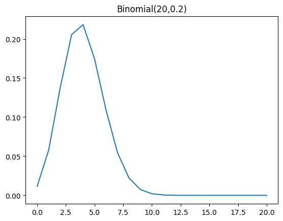

```python
binomial_plot(20,0.2)
```

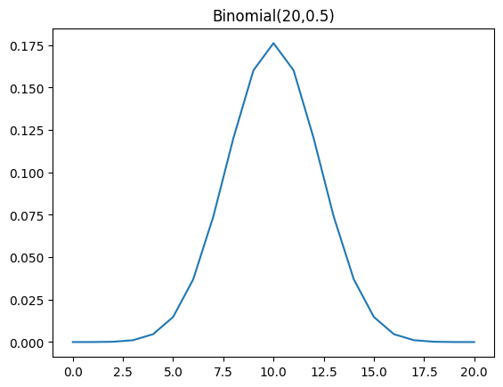

```python
binomial_plot(20,0.5)
```

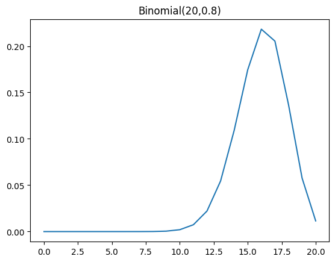

```python
binomial_plot(20,0.8)
```

## Examples

1. Let $X$ be a a binomial random variable with parameters $n=9$ and $p=0.4$.
   1. Compute $P\{X=4\}$.
   2. Compute $P\{X=9\}$.
   3. Compute $P\{X=11\}$.
2. Suppose you flip a fair coin 10 times. What is the probability that you flip exactly 4 heads?
3. A multiple-choice examination has 3 possible answers for each of 5 questions. What is the probability of getting 4 or more correct answers just by guessing?
4. Each diskette produced by a certain company will be defective with probability 0.05 independent of the others. The company sells the diskettes in packages of 10 and offers a money-back guarantee that all the diskettes in a package will be nondefective. Suppose that this offer is always taken up. What is the probability that a package is returned?

## Expected Value and Variance of a Binomial Randon Variable

Let $X$ be a binomial random variable with parameters $n$ and $p$. Then $$X = \sum_{i=1}^n X_i$$ the $X_i's$ are Bernoulli random variables with probability of success $p$. Using our formulas from last time: $$E[X] = nE[X_1] = np$$ and $$Var(X) = nVar(X_1) = np(1-p).$$ (Remember independence!)

## Examples

1. A fair, 6-sided die is rolled 20 times. Find the expected value and standard deviation of the number of times 4 appears.
2. If $X$ is a random variable with expected value 4.5 and variance 0.45, find $P\{X=3\}.$